# Métodos Cuantitativos en Ecología - MCE5

EXAMEN FINAL - 2022II

Karina Olalla

11-07-2023

Los contenidos de esta evaluación corresponden a los temas:

- GLM y GAM
- Introducción a estadística Bayesiana
- Series de tiempo
- Análisis espacial

Ustedes estan utilizando un archivo tipo R Markdown (`.Rmd`). Las instruciones son **[1 PUNTO]**:

- Bifurquen el repositorio en GitHub y clonen en su computador usando un proyecto con control de la versión de RStudio.
- Arriba, donde dice “author”, deben llenar sus nombres.
- **Todo resultado debe ir con su explicación y/o discusión, caso contrario no se calificará.**
- **NO IMPRIMA los datos o tablas completas**, reporte únicamente figuras o tablas resumen. Si tiene varias figuras use la función `ggarrange` de la librería `ggpubr`.
- Al final de este examen deben utilizar el comando “Knit” para generar un archivo HTML.
- **Cada pregunta debe tener al menos un cntrol de la versión**.
- Su entrega consiste en colocar el **enlace de GitHub** en la actividad “ExamenFinal”.

## **PREGUNTA 1: GLM, GAM y Regresión Bayesiana [3 PUNTOS]**

En el archivo `"glm.xlsx"` tiene tres datos:

- aedes: insecticidas utilizados para controlar el número de mosquitos en un experimento. Cada vez que se repite la aplicación del insecticida parece disminuir la cantidad de zancudos vivos.
- leishmania: en una infección con leishmania cuando se analiza el tejido qué sucede con la concentración de algunas células y si están o no afectadas.
- disease: cómo la edad afecta a diferentes características dicotómicas.

Realice los siguientes análisis:

- aedes: GLM Poisson
- disease: GLMs binomiales
- leishmania: glm bayesiano

Realizar los siguientes análisis y respectivas interpretaciones:

1. Análisis exploratorio.

```r
library(readxl)
glm <- read_excel("glm.xlsx")
View(glm)
#Analisis exploratorio
head(glm)
```

```
## # A tibble: 6 x 3
##   agrochem repetition aedes
##   <chr>         <dbl> <dbl>
## 1 A                 1  2370
## 2 B                 1  1282
## 3 C                 1   562
## 4 D                 1   173
## 5 E                 1   193
## 6 A                 2  1687
```

```r
summary(glm)
```

```
##    agrochem           repetition      aedes
##  Length:30          Min.   :1.0   Min.   :  44.0
##  Class :character   1st Qu.:2.0   1st Qu.: 136.5
##  Mode  :character   Median :3.5   Median : 523.5
##                     Mean   :3.5   Mean   : 865.4
##                     3rd Qu.:5.0   3rd Qu.:1217.8
##                     Max.   :6.0   Max.   :3020.0
```

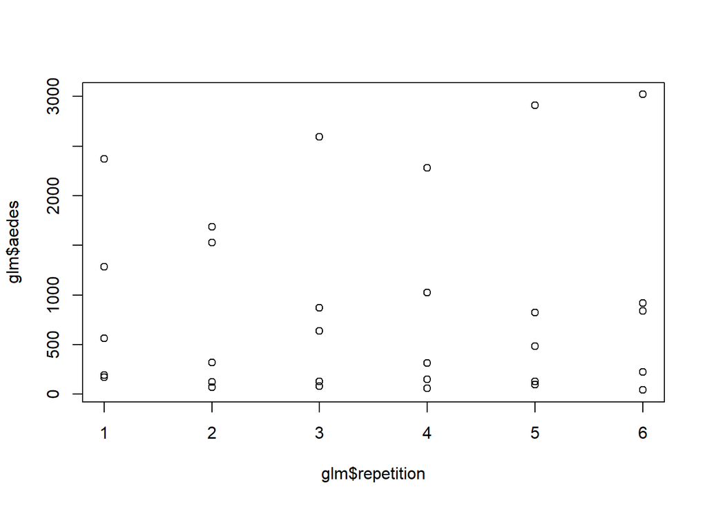

```r
plot(glm$repetition, glm$aedes)
```

2. Planteamiento de hipótesis. $H.nula$ La cantidad de mosquitos no varía con relación a la repetición de la aplicación del insecticida $H.alterna$ La cantidad de mosquitos varía con relación a la repetición de la aplicación del insecticida
3. Análisis de regresión
4. Planteamiento del modelo.
5. Validez del modelo.

## **PREGUNTA 2: Series de tiempo [3 PUNTOS]**

En el archivo `"ts.xlsx"` tiene tres datos:

- quakes: cantidad de eventos de terremotos por cada año.
- hepatitis: casos de hepatitis por mes entre 2010 y 2017 (acomodar la tabla si es necesario)
- wildfire: cantidad de eventos de incendios forestales por mes entre 2003 y 2017.

Realizar los siguientes análisis y respectivas interpretaciones:

1. Análisis exploratorio: autocorrelación y descomposición, análisis estacional.

## **PREGUNTA 3: Análisis espacial de especies [3 PUNTOS]**

Seleccione una especie de planta y una especie de animal; asimismo, dos tipos de modelos de predicción (glm, gam, rf, ann, otro):

- Mosquito: *Aedes aegypti*
- Puma: *Puma concolor*
- Coati: *Nasua nasua*
- Tapir: *Tapirus terrestris*
- Jaguar: *Panthera onca*
- Palma de cera: *Ceroxylon quindiuense*
- Ceibo: *Ceiba pentandra*
- Pasiflora: *Passiflora edulis*
- Chirimoya: *Anona cherimola*

Luego realice un análisis espacial de distribución de la especie en Ecuador continental en base a los datos de presencia del GBIF (use rgbif para descargar la data). Explique el resultado y compare la diferencia entre la salida de los dos modelos. En qué regiones los modelos difieren más en la predicción?

```r
library(rgbif)
library(tidyverse)
occ = occ_data(scientificName = 'Tremarctos ornatus',
                limit = 200000,
                hasCoordinate = TRUE,
                hasGeospatialIssue = FALSE)

occ_col <- filter(occ$data, country == 'Ecuador')
shp <- raster::getData('GADM', country = 'ECU', level = 1)
```

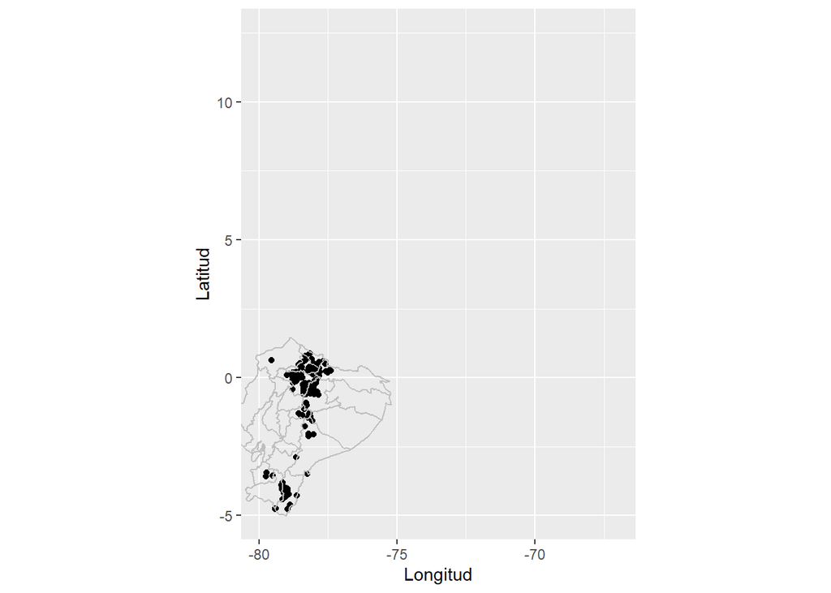

```r
gg <- ggplot() +
  geom_point(data = occ_col, aes(x = decimalLongitude, y = decimalLatitude), color = 'black') +
  geom_polygon(data = shp, aes(x = long, y = lat, group = group), color = 'grey', fill = NA) +
  coord_fixed(ylim = c(-5, 12.5), xlim = c(-80, -67)) +
  xlab('Longitud') +
  ylab('Latitud')
ggsave(plot = gg, filename = 'Tremarctos ornatus.png', units = 'cm', width = 12, height = 16, dpi = 300)

gg
```

En esta gráfica se puede observar la distribución de Tremarctos ornatus en el territorio , se puede observar que hay una mayor cantidad de Termarctos ornatus en la parte superior de la Sierra ecuatoriana, también se puede observar que algunas especies están presentes en Zamora Chinchipe